# Regression Output in R

Author

Wade K. Copeland

Published

October 13, 2025

# Introduction

The general linear model (GLM), more commonly called linear regression, is a common statistical modeling tool a statistician or data scientist will use. As such, it is crucial to know how to present results from a GLM in a way that is understandable to your audience.

The GLM assumes that the conditional distribution of the $i^{th}$ response is normal with expectation that is a linear function of a set of $p$ predictors with uncorrelated errors that represent the aggregate omitted causes of $Y$ (Equation 1) (Fox 2008).

$$\begin{equation}
Y_{i} \sim N(\beta_0 + X_{i1}\beta_{1} + + X_{i2}\beta_{2} + ... + X_{ip}\beta_{p}, \sigma_{\epsilon}^2)
\end{equation}
\tag{1}$$

This presentation uses the R programming language and assumes the end user is taking advantage of RStudio IDE to compile their R markdown files into HTML (R Core Team 2019; RStudio Team 2016). All of the files needed to reproduce these results can be downloaded from the Git repository https://github.com/wkingc/regression-output-in-r.

# Required Libraries

The libraries *knitr*, *bookdown*, and *kableExtra* are used to generate the HTML output (Xie 2019, 2018; Zhu 2019). The *ggplot2* library is loaded for the example data set that is used in this presentation (Wickham 2016). The *Hmisc* library provides functionality needed to create variable labels (Harrell Jr, Charles Dupont, and others. 2019). Regression diagnostics are plotted using the *ggfortify* package (Tang, Horikoshi, and Li 2016). The *stargazer* library will be used create nice looking regression output (Hlavac 2018).

```r
library("knitr")
library("bookdown")
library("kableExtra")
library("ggplot2")
library("Hmisc")
library("ggfortify")
library("stargazer")
```

# Example Data Setup

The data set used in this presentation is **mpg** from the *ggplot2* package. From the description in the manual:

> This dataset contains a subset of the fuel economy data that the EPA makes available [here](http://fueleconomy.gov). It contains only models which had a new release every year between 1999 and 2008 - this was used as a proxy for the popularity of the car.

```r
set.seed(123)
data(mpg)
mpg <- data.frame(mpg)

colnames(mpg)[which(colnames(mpg) == "manufacturer")] <- "manu"

mpg$manu <- factor(mpg$manu)
mpg$model <- factor(mpg$model)
mpg$displ <- as.numeric(mpg$displ)
mpg$year <- factor(mpg$year, levels = c("1999", "2008"), ordered = TRUE)

mpg$dp <- as.Date(NA, origin = "1970-01-01")
mpg$dp[which(mpg$year == "1999")] <- sample(seq(as.Date('1999-01-01', format = "%Y-%m-%d", origin = "1970-01-01"), as.Date('1999-12-25', format = "%Y-%m-%d", origin = "1970-01-01"), by = "day"), dim(mpg)[1]/2)
mpg$dp[which(mpg$year == "2008")] <- sample(seq(as.Date('2008-01-01', format = "%Y-%m-%d", origin = "1970-01-01"), as.Date('2008-12-25', format = "%Y-%m-%d", origin = "1970-01-01"), by = "day"), dim(mpg)[1]/2)

mpg$cyl <- factor(mpg$cyl, levels = c(4, 5, 6, 8), ordered = TRUE)
mpg$trans <- factor(mpg$trans)
mpg$drv <- factor(mpg$drv, levels = c("f", "r", "4"), labels = c("front-wheel drive", "rear wheel drive", "4wd"))
mpg$fl <- factor(mpg$fl)
mpg$class <- factor(mpg$class)

mpg$rn <- rnorm(dim(mpg)[1], mean = 10, sd = 5)
mpg$rn[sample(1:length(mpg$rn), size = 50)] <- NA

mpg$party <- factor(sample(c("republican", "democrat", "independent", NA), dim(mpg)[1], replace = TRUE), levels = c("republican", "democrat", "independent"))
mpg$comments <- sample(c("I like this car!", "Meh.", "This is the worst car ever!", "Does it come in green?", "want cheese flavoured cars.", "Does it also fly?", "Blah, Blah, Blah, Blah, Blah, Blah, Blah, Blah", NA), dim(mpg)[1], replace = TRUE)

label(mpg$manu) <- "manufacturer"
label(mpg$model) <- "model name"
label(mpg$displ) <- "engine displacement, in litres"
label(mpg$year) <- "year of manufacture"
label(mpg$dp) <- "date of purchase"
label(mpg$cyl) <- "number of cylinders"
label(mpg$trans) <- "type of transmission"
label(mpg$drv) <- "drive type"
label(mpg$cty) <- "city miles per gallon"
label(mpg$hwy) <- "highway miles per gallon"
label(mpg$fl) <- "fuel type"
label(mpg$class) <- "type of car"
label(mpg$rn) <- "some random numbers that are generated from a normal distrubtion with mean = 10 and sd = 5"
label(mpg$party) <- "some random political parties"
label(mpg$comments) <- "some random comments"

kable(head(mpg), caption = "Header of <b>mpg</b>.", booktabs = TRUE, escape = FALSE) %>% kable_styling(bootstrap_options = c("striped", "hover", "condensed", "responsive"))
```

Header of **mpg**.

| manu | model | displ | year | cyl | trans | drv | cty | hwy | fl | class | dp | rn | party | comments |
| --- | --- | --- | --- | --- | --- | --- | --- | --- | --- | --- | --- | --- | --- | --- |
| audi | a4 | 1.8 | 1999 | 4 | auto(l5) | front-wheel drive | 18 | 29 | p | compact | 1999-06-28 | 18.98570 | democrat | I like this car! |
| audi | a4 | 1.8 | 1999 | 4 | manual(m5) | front-wheel drive | 21 | 29 | p | compact | 1999-01-14 | NA | NA | I like this car! |
| audi | a4 | 2.0 | 2008 | 4 | manual(m6) | front-wheel drive | 20 | 31 | p | compact | 2008-02-08 | 19.50450 | independent | Does it also fly? |
| audi | a4 | 2.0 | 2008 | 4 | auto(av) | front-wheel drive | 21 | 30 | p | compact | 2008-07-14 | NA | independent | I like this car! |
| audi | a4 | 2.8 | 1999 | 6 | auto(l5) | front-wheel drive | 16 | 26 | p | compact | 1999-07-14 | 13.68097 | democrat | Meh. |
| audi | a4 | 2.8 | 1999 | 6 | manual(m5) | front-wheel drive | 18 | 26 | p | compact | 1999-11-02 | 16.82888 | NA | Meh. |

# City MPG Regression

$$\begin{equation}
\begin{split}
cty_{i} = \beta_0 + dipl_{i}\beta_{1} + year_{i}\beta_{2} + cyl_{i}\beta_{3} + drv_{i}\beta_{4} + \\
\\class_{i}\beta_{5} + rn_{i}\beta_{6} + party_{i}\beta_{7} + \epsilon_{i}
\end{split}
\end{equation}
\tag{2}$$

$$\begin{equation}
\begin{split}
hwy_{i} = \beta_0 + dipl_{i}\beta_{1} + year_{i}\beta_{2} + cyl_{i}\beta_{3} + drv_{i}\beta_{4} + \\
\\class_{i}\beta_{5} + rn_{i}\beta_{6} + party_{i}\beta_{7} + \epsilon_{i}
\end{split}
\end{equation}
\tag{3}$$

## Regression Diagnostics

The regression diagnostics show a few problems. The residuals vs. fitted plot shows a few points that have large residuals. These points translate to a normal quantile plot with a large discrepancy between the standardized residuals and the theoretical quantiles on the tail. From the scale location plots, we see relative homoscedasticity except for the outliers. The plot of Cook’s distance, a measure of influence on the fit, shows that the outliers have a disproportionate influence on the estimates in the final fit.

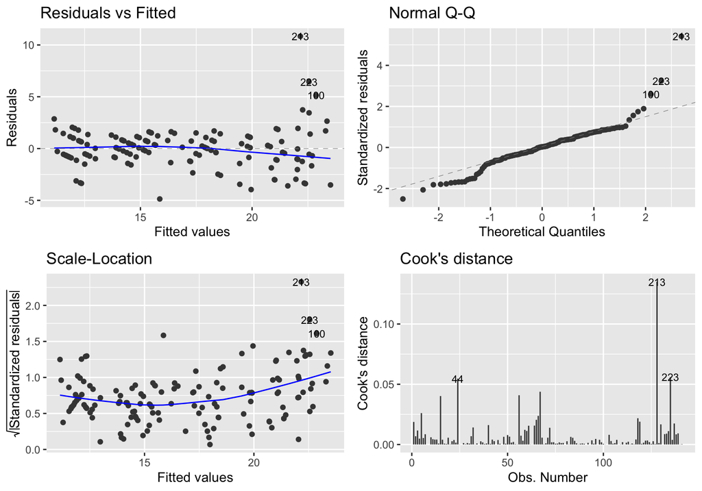

City MPG Regression Diagnostics

```r
ctyFit <- lm(cty ~ displ + year + cyl + drv + class + rn + party, data = mpg)

autoplot(ctyFit, which = c(1, 2, 3, 4), ncol = 2, label.size = 3)
```

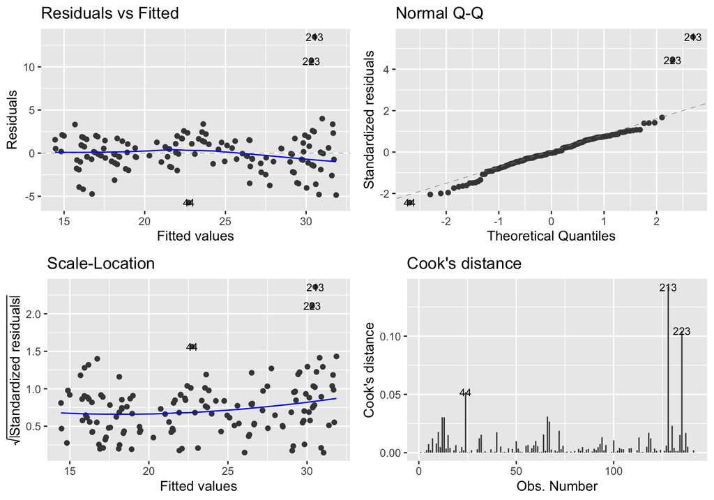

Highway MPG Regression Diagnostics

```r
hwyFit <- lm(hwy ~ displ + year + cyl + drv + class + rn + party, data = mpg)

autoplot(hwyFit, which = c(1, 2, 3, 4), ncol = 2, label.size = 3)
```

## Regression Output

The regression starts with re-fitting the models with the problem points removed. Finally, we use the *stargazer* function to print the results. To customzie the disply the results, we also need a bit of css which can be downloaded [here](https://github.com/wkingc/regression-output-in-r/blob/main/regression_output_in_r.css). The *id* for the CSS is generated by adding *{#regression}* to the header of this section. Check the [markdown](https://github.com/wkingc/regression-output-in-r/blob/main/regression_output_in_r.qmd) to see it in context.

```r
ctyFit <- lm(cty ~ displ + year + cyl + drv + class + rn + party, data = mpg[c(-213, -223), ])

hwyFit <- lm(hwy ~ displ + year + cyl + drv + class + rn + party, data = mpg[c(-213, -223), ])

depLabels <- c(label(mpg$cty), label(mpg$hwy))

indepLabels <- c(
    "intercept",
    label(mpg$displ),
    paste(label(mpg$year), ": ", levels(mpg$year)[2], " (ref = ", levels(mpg$year)[1], ")", sep = ""),
    paste(label(mpg$cyl), ": ", levels(mpg$cyl)[2], " (ref = ", levels(mpg$cyl)[1], ")", sep = ""),
    paste(label(mpg$cyl), ": ", levels(mpg$cyl)[3], " (ref = ", levels(mpg$cyl)[1], ")", sep = ""),
    paste(label(mpg$cyl), ": ", levels(mpg$cyl)[4], " (ref = ", levels(mpg$cyl)[1], ")", sep = ""),
    paste(label(mpg$drv), ": ", levels(mpg$drv)[2], " (ref = ", levels(mpg$drv)[1], ")", sep = ""),
    paste(label(mpg$drv), ": ", levels(mpg$drv)[3], " (ref = ", levels(mpg$drv)[1], ")", sep = ""),
    paste(label(mpg$class), ": ", levels(mpg$class)[2], " (ref = ", levels(mpg$class)[1], ")", sep = ""),
    paste(label(mpg$class), ": ", levels(mpg$class)[3], " (ref = ", levels(mpg$class)[1], ")", sep = ""),
    paste(label(mpg$class), ": ", levels(mpg$class)[4], " (ref = ", levels(mpg$class)[1], ")", sep = ""),
    paste(label(mpg$class), ": ", levels(mpg$class)[5], " (ref = ", levels(mpg$class)[1], ")", sep = ""),
    paste(label(mpg$class), ": ", levels(mpg$class)[6], " (ref = ", levels(mpg$class)[1], ")", sep = ""),
    paste(label(mpg$class), ": ", levels(mpg$class)[7], " (ref = ", levels(mpg$class)[1], ")", sep = ""),
    label(mpg$rn),
    paste(label(mpg$party), ": ", levels(mpg$party)[2], " (ref = ", levels(mpg$party)[1], ")", sep = ""),
    paste(label(mpg$party), ": ", levels(mpg$party)[3], " (ref = ", levels(mpg$party)[1], ")", sep = "")
)

stargazer(
    ctyFit, hwyFit, type = "html",
    title = "Regression Results",
    dep.var.labels = depLabels,
    covariate.labels = indepLabels,
    ci = TRUE,
    ci.level = 0.95,
    single.row = TRUE,
    align = TRUE,
    intercept.bottom = FALSE,
    intercept.top = TRUE
)
```

**Regression Results**

|  | *Dependent variable:* |  |
| --- | --- | --- |
|  | city miles per gallon | highway miles per gallon |
|  | (1) | (2) |
| intercept | 22.750*** (18.368, 27.132) | 33.366*** (28.412, 38.320) |
| engine displacement, in litres | -0.382 (-1.231, 0.466) | -0.648 (-1.607, 0.311) |
| year of manufacture: 2008 (ref = 1999) | 0.601*** (0.167, 1.035) | 0.991*** (0.501, 1.482) |
| number of cylinders: 5 (ref = 4) | -3.414*** (-5.096, -1.731) | -3.302*** (-5.204, -1.400) |
| number of cylinders: 6 (ref = 4) | -0.173 (-1.277, 0.930) | -0.162 (-1.409, 1.085) |
| number of cylinders: 8 (ref = 4) | -0.408 (-1.773, 0.957) | -0.469 (-2.012, 1.074) |
| drive type: rear wheel drive (ref = front-wheel drive) | -1.964** (-3.541, -0.387) | -1.585* (-3.368, 0.197) |
| drive type: 4wd (ref = front-wheel drive) | -2.141*** (-3.285, -0.996) | -2.844*** (-4.138, -1.551) |
| type of car: compact (ref = 2seater) | -2.217 (-5.161, 0.727) | -3.440** (-6.768, -0.112) |
| type of car: midsize (ref = 2seater) | -2.712* (-5.704, 0.281) | -3.874** (-7.257, -0.491) |
| type of car: minivan (ref = 2seater) | -4.975*** (-8.102, -1.847) | -7.913*** (-11.448, -4.378) |
| type of car: pickup (ref = 2seater) | -4.025*** (-6.911, -1.138) | -8.987*** (-12.250, -5.724) |
| type of car: subcompact (ref = 2seater) | -1.453 (-4.320, 1.414) | -3.592** (-6.833, -0.351) |
| type of car: suv (ref = 2seater) | -3.673*** (-6.397, -0.950) | -7.731*** (-10.810, -4.653) |
| some random numbers that are generated from a normal distrubtion with mean = 10 and sd = 5 | -0.039 (-0.092, 0.015) | -0.053* (-0.113, 0.008) |
| some random political parties: democrat (ref = republican) | -0.169 (-0.973, 0.634) | -0.517 (-1.425, 0.392) |
| some random political parties: independent (ref = republican) | -0.175 (-0.937, 0.587) | -0.298 (-1.160, 0.563) |
| Observations | 139 | 139 |
| R<sup>2</sup> | 0.830 | 0.891 |
| Adjusted R<sup>2</sup> | 0.807 | 0.876 |
| Residual Std. Error (df = 122) | 1.722 | 1.946 |
| F Statistic (df = 16; 122) | 37.128*** | 62.027*** |
| *Note:* | *p<0.1; **p<0.05;*** p<0.01 |  |

## Regression Summary

```r
ctyCoef <- coef(ctyFit)
ctyConf <- confint(ctyFit)
ctyRes <- cbind(ctyCoef, ctyConf)

hwyCoef <- coef(hwyFit)
hwyConf <- confint(hwyFit)
hwyRes <- cbind(hwyCoef, hwyConf)

inlineReg <- function(x, lab) {
    r1 <- round(x[lab, 1], 1)
    r2 <- round(x[lab, 2], 1)
    r3 <- round(x[lab, 3], 1)

    res <- paste(r1, " (95% CI = [", r2, ",", r3, "])", sep = "")

    return(res)
}
```

## References

Fox, John. 2008. *Applied Regression Analysis and Generalized Linear Models*. Sage Publications.

Harrell Jr, Frank E, with contributions from Charles Dupont, and many others. 2019. *Hmisc: Harrell Miscellaneous*. https://CRAN.R-project.org/package=Hmisc.

Hlavac, Marek. 2018. *Stargazer: Well-Formatted Regression and Summary Statistics Tables*. Bratislava, Slovakia: Central European Labour Studies Institute (CELSI). https://CRAN.R-project.org/package=stargazer.

R Core Team. 2019. *R: A Language and Environment for Statistical Computing*. Vienna, Austria: R Foundation for Statistical Computing. https://www.R-project.org/.

RStudio Team. 2016. *RStudio: Integrated Development Environment for r*. Boston, MA: RStudio, Inc. http://www.rstudio.com/.

Tang, Yuan, Masaaki Horikoshi, and Wenxuan Li. 2016. “Ggfortify: Unified Interface to Visualize Statistical Result of Popular r Packages.” *The R Journal* 8. https://journal.r-project.org/.

Wickham, Hadley. 2016. *Ggplot2: Elegant Graphics for Data Analysis*. Springer-Verlag New York. http://ggplot2.org.

Xie, Yihui. 2018. *Bookdown: Authoring Books and Technical Documents with r Markdown*. https://github.com/rstudio/bookdown.

———. 2019. *Knitr: A General-Purpose Package for Dynamic Report Generation in r*. https://yihui.name/knitr/.

Zhu, Hao. 2019. *kableExtra: Construct Complex Table with ’Kable’ and Pipe Syntax*. https://CRAN.R-project.org/package=kableExtra.